# 1_Cyp27a1_coverage: read coverage over Cyp27a1 exons in WT and KO

Published

October 30, 2026

## Overview

The *Cyp27a1* KO samples still show *Cyp27a1* reads at the gene level (`0_QC`). Here, per-base coverage from the nf-core/rnaseq bigwigs is plotted over the exons of the canonical transcript to locate the targeted region: a deleted exon should show a loss of coverage in all KO samples relative to the remaining exons.

- The library is stranded: only the sense-strand bigwig is used (`.forward` for genes on +, `.reverse` for genes on −; checked below).
- Bigwigs contain raw coverage. Coverage is scaled to reads per million using the TMM effective library sizes from `0_QC/outputs/files/dge.rds`.
- Exons are taken from the frozen GENCODE vM25 GTF (`data/gencode.vM25.primary_assembly.annotation.gtf.gz`, see `0_QC/downloadAnnotation.R`).

```r
library(rtracklayer)
library(GenomicRanges)
library(edgeR)
library(tidyverse)
library(patchwork)
library(yaml)
library(here)

source(here("functions", "formatting_ggplot.R"))
config <- read_yaml(here("config.yaml"))
genotype_colors <- unlist(config$genotype_colors)

fig_dir <- here("1_Cyp27a1_coverage", "outputs", "figures")
files_dir <- here("1_Cyp27a1_coverage", "outputs", "files")
bw_dir <- here("data", "nfcore_rnaseq", "bigwig")

save_fig <- function(p, name, width, height) {
  ggsave(file.path(fig_dir, name), p, width = width, height = height)
  p
}
```

## Gene model

The canonical transcript is the protein-coding CCDS transcript with the most exons. Exons are numbered 5’ to 3’.

```r
gtf <- import(
  here("data", "gencode.vM25.primary_assembly.annotation.gtf.gz"),
  feature.type = c("gene", "transcript", "exon")
)
gene_gtf <- gtf[!is.na(gtf$gene_name) & gtf$gene_name == params$gene]
rm(gtf)

gene_gr <- gene_gtf[gene_gtf$type == "gene"]
gene_strand <- as.character(strand(gene_gr))

tx <- gene_gtf[gene_gtf$type == "transcript"]
tx_df <- tibble(
  transcript_id = tx$transcript_id,
  transcript_type = tx$transcript_type,
  ccds = map_lgl(tx$tag, \(x) "CCDS" %in% x),
  n_exons = map_int(transcript_id, \(id) sum(gene_gtf$type == "exon" & gene_gtf$transcript_id %in% id)),
  width = width(tx)
)
knitr::kable(tx_df)
```

| transcript_id | transcript_type | ccds | n_exons | width |
| --- | --- | --- | --- | --- |
| ENSMUST00000027356.6 | protein_coding | TRUE | 9 | 24319 |
| ENSMUST00000190781.1 | retained_intron | FALSE | 3 | 1366 |
| ENSMUST00000189083.1 | retained_intron | FALSE | 3 | 1015 |

```r
canonical_tx <- tx_df |>
  filter(transcript_type == "protein_coding") |>
  arrange(desc(ccds), desc(n_exons), desc(width)) |>
  pull(transcript_id) |>
  first()

exons <- gene_gtf[gene_gtf$type == "exon" & gene_gtf$transcript_id %in% canonical_tx]
exons <- sort(exons, decreasing = gene_strand == "-")
exons$exon <- paste0("E", seq_along(exons))
exons <- sort(exons)

exon_df <- as.data.frame(exons) |>
  dplyr::select(exon, seqnames, start, end, width, strand, exon_id) |>
  mutate(exon = factor(exon, levels = paste0("E", seq_along(exons))))

write.csv(exon_df, file.path(files_dir, "exons_canonical.csv"), row.names = FALSE)
knitr::kable(exon_df)
```

| exon | seqnames | start | end | width | strand | exon_id |
| --- | --- | --- | --- | --- | --- | --- |
| E1 | chr1 | 74713574 | 74713891 | 318 | + | ENSMUSE00000269437.3 |
| E2 | chr1 | 74731919 | 74732109 | 191 | + | ENSMUSE00000269429.3 |
| E3 | chr1 | 74735277 | 74735476 | 200 | + | ENSMUSE00000156478.3 |
| E4 | chr1 | 74735554 | 74735751 | 198 | + | ENSMUSE00000156477.5 |
| E5 | chr1 | 74735864 | 74736036 | 173 | + | ENSMUSE00000269410.5 |
| E6 | chr1 | 74736681 | 74736847 | 167 | + | ENSMUSE00000156484.3 |
| E7 | chr1 | 74737017 | 74737098 | 82 | + | ENSMUSE00000156483.3 |
| E8 | chr1 | 74737179 | 74737391 | 213 | + | ENSMUSE00000156481.3 |
| E9 | chr1 | 74737543 | 74737892 | 350 | + | ENSMUSE00000269370.4 |

## Load coverage

```r
dge <- readRDS(here("0_QC", "outputs", "files", "dge.rds"))
samples <- dge$samples |>
  dplyr::select(sample_id, mouse, genotype, lib.size, norm.factors) |>
  mutate(
    genotype = factor(genotype, levels = c("WT", "KO")),
    scale = 1e6 / (lib.size * norm.factors)
  )

locus <- range(gene_gr)

read_cov <- function(sample_id, strand_suffix) {
  import(
    file.path(bw_dir, paste0(sample_id, strand_suffix, ".bigWig")),
    which = locus,
    as = "NumericList"
  )[[1]]
}

# per-base raw coverage over the gene locus, sense and antisense strand
sense_suffix <- if (gene_strand == "+") ".forward" else ".reverse"
antisense_suffix <- if (gene_strand == "+") ".reverse" else ".forward"

cov_sense <- map(set_names(samples$sample_id), \(s) read_cov(s, sense_suffix))
cov_antisense <- map(set_names(samples$sample_id), \(s) read_cov(s, antisense_suffix))
```

### Strand check

In a stranded library, almost all reads over an exon should come from the sense-strand bigwig.

```r
in_exon <- (start(locus):end(locus)) %in% unlist(as(ranges(exons), "IntegerList"))

tibble(
  sample_id = samples$sample_id,
  sense = map_dbl(cov_sense, \(x) sum(x[in_exon])),
  antisense = map_dbl(cov_antisense, \(x) sum(x[in_exon]))
) |>
  mutate(pct_sense = 100 * sense / (sense + antisense)) |>
  knitr::kable(digits = 1)
```

| sample_id | sense | antisense | pct_sense |
| --- | --- | --- | --- |
| A1_WT_Epi | 149433 | 3131 | 97.9 |
| A2_WT_Epi | 147559 | 5789 | 96.2 |
| A3_WT_Epi | 134407 | 1271 | 99.1 |
| B1_KO_Epi | 134010 | 5861 | 95.8 |
| B2_KO_Epi | 111759 | 726 | 99.4 |
| B3_KO_Epi | 77243 | 1785 | 97.7 |

```r
cov_df <- imap(cov_sense, \(x, s) {
  tibble(sample_id = s, pos = start(locus):end(locus), raw = as.numeric(x))
}) |>
  list_rbind() |>
  left_join(samples, by = "sample_id") |>
  mutate(cov = raw * scale)

# exon membership of each position
exon_hits <- findOverlaps(
  GRanges(seqnames(locus), IRanges(start(locus):end(locus), width = 1)),
  exons
)
pos_exon <- rep(NA_character_, width(locus))
pos_exon[queryHits(exon_hits)] <- exons$exon[subjectHits(exon_hits)]

cov_df <- cov_df |>
  mutate(exon = pos_exon[pos - start(locus) + 1])
```

## Coverage over the locus

Coverage scaled to reads per million (TMM). Shaded areas are exons of the canonical transcript; the line is the genotype mean and the ribbon the range across mice.

```r
exon_rect <- exon_df |>
  mutate(mid = (start + end) / 2)

gene_model <- function(xvar_start, xvar_end, xmid) {
  ggplot(exon_rect) +
    geom_hline(yintercept = 0, linewidth = .3) +
    geom_rect(
      aes(xmin = {{ xvar_start }}, xmax = {{ xvar_end }}, ymin = -1, ymax = 1),
      fill = "black"
    ) +
    geom_text(aes(x = {{ xmid }}, y = -2.3, label = exon), size = 3.5) +
    scale_y_continuous(limits = c(-3, 1.2)) +
    theme_void()
}

exon_shading <- function(xvar_start, xvar_end) {
  geom_rect(
    data = exon_rect,
    aes(xmin = {{ xvar_start }}, xmax = {{ xvar_end }}, ymin = -Inf, ymax = Inf),
    inherit.aes = FALSE,
    fill = "grey90"
  )
}

summarise_genotype <- function(df, x) {
  df |>
    group_by(genotype, {{ x }}) |>
    summarise(mean = mean(cov), min = min(cov), max = max(cov), .groups = "drop")
}
```

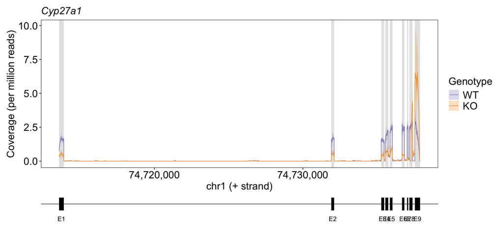

```r
locus_genotype <- summarise_genotype(cov_df, pos)

p_locus <- ggplot(locus_genotype, aes(x = pos)) +
  exon_shading(start, end) +
  geom_ribbon(aes(ymin = min, ymax = max, fill = genotype), alpha = .3) +
  geom_line(aes(y = mean, color = genotype), linewidth = .4) +
  scale_fill_manual(values = genotype_colors) +
  scale_color_manual(values = genotype_colors) +
  scale_x_continuous(labels = scales::label_comma()) +
  my_theme +
  theme(plot.title = element_text(face = "italic")) +
  labs(
    x = paste0(seqnames(locus), " (", gene_strand, " strand)"),
    y = "Coverage (per million reads)",
    color = "Genotype",
    fill = "Genotype",
    title = params$gene
  )

p_locus_model <- p_locus / (gene_model(start, end, mid) + coord_cartesian(xlim = range(cov_df$pos))) +
  plot_layout(heights = c(5, 1))

save_fig(p_locus_model, "coverage_locus_genotype.pdf", 11, 5)
```

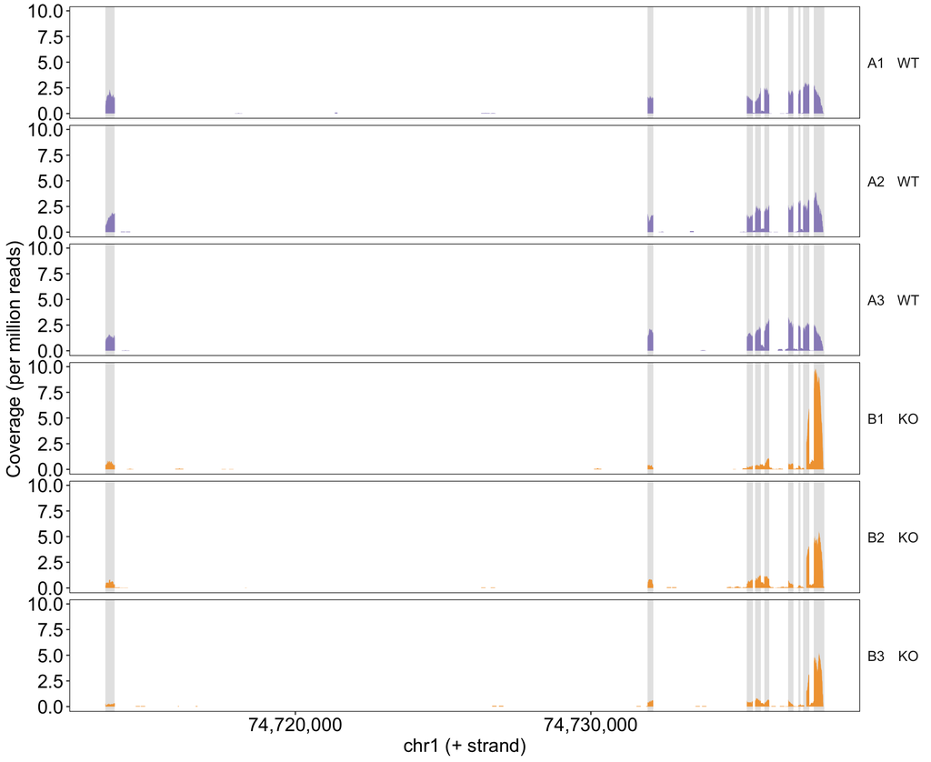

```r
p_locus_sample <- ggplot(cov_df, aes(x = pos, y = cov)) +
  exon_shading(start, end) +
  geom_area(aes(fill = genotype)) +
  facet_wrap(~ genotype + mouse, ncol = 1, strip.position = "right") +
  scale_fill_manual(values = genotype_colors) +
  scale_x_continuous(labels = scales::label_comma()) +
  my_theme +
  theme(
    strip.background = element_blank(),
    strip.text.y = element_text(size = 12, angle = 0),
    legend.position = "none"
  ) +
  labs(
    x = paste0(seqnames(locus), " (", gene_strand, " strand)"),
    y = "Coverage (per million reads)"
  )

save_fig(p_locus_sample, "coverage_locus_sample.pdf", 11, 9)
```

## Coverage over exons only

Introns removed and exons concatenated (5’ to 3’ left to right on the genome), so each exon is visible regardless of intron length.

```r
gap <- 30
exon_rect <- exon_rect |>
  arrange(start) |>
  mutate(
    x_start = cumsum(lag(width + gap, default = 0)),
    x_end = x_start + width,
    x_mid = (x_start + x_end) / 2
  )

cov_exon_df <- cov_df |>
  filter(!is.na(exon)) |>
  left_join(exon_rect |> dplyr::select(exon, start, x_start), by = "exon") |>
  mutate(x = x_start + pos - start)
```

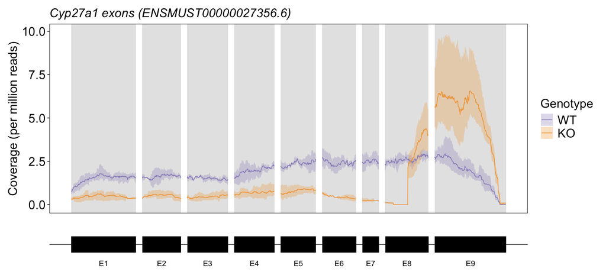

```r
exon_genotype <- cov_exon_df |>
  group_by(genotype, exon, x) |>
  summarise(mean = mean(cov), min = min(cov), max = max(cov), .groups = "drop")

p_exon <- ggplot(exon_genotype, aes(x = x, group = interaction(genotype, exon))) +
  exon_shading(x_start, x_end) +
  geom_ribbon(aes(ymin = min, ymax = max, fill = genotype), alpha = .3) +
  geom_line(aes(y = mean, color = genotype), linewidth = .4) +
  scale_fill_manual(values = genotype_colors) +
  scale_color_manual(values = genotype_colors) +
  my_theme +
  theme(
    axis.text.x = element_blank(),
    axis.ticks.x = element_blank(),
    plot.title = element_text(face = "italic")
  ) +
  labs(
    x = "",
    y = "Coverage (per million reads)",
    color = "Genotype",
    fill = "Genotype",
    title = paste0(params$gene, " exons (", canonical_tx, ")")
  )

p_exon_model <- p_exon / (gene_model(x_start, x_end, x_mid) + coord_cartesian(xlim = range(cov_exon_df$x))) +
  plot_layout(heights = c(5, 1))

save_fig(p_exon_model, "coverage_exons_genotype.pdf", 11, 5)
```

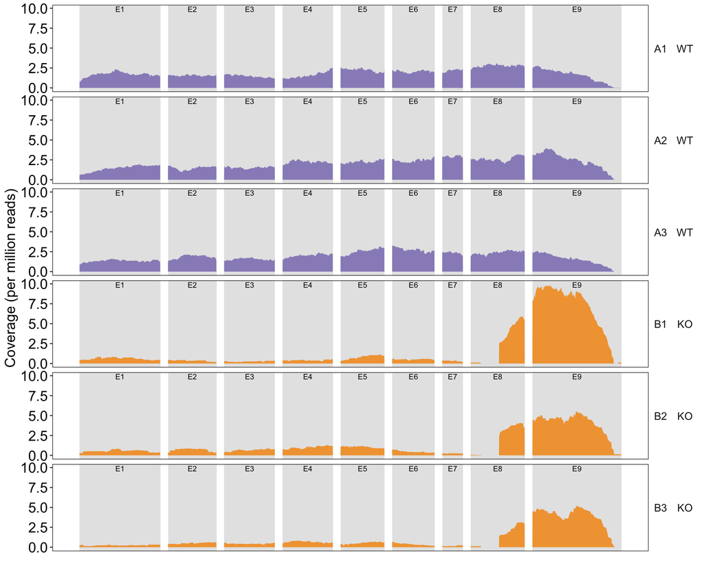

```r
p_exon_sample <- ggplot(cov_exon_df, aes(x = x, y = cov, group = exon)) +
  exon_shading(x_start, x_end) +
  geom_area(aes(fill = genotype)) +
  geom_text(
    data = exon_rect,
    aes(x = x_mid, y = Inf, label = exon),
    inherit.aes = FALSE,
    vjust = 1.3,
    size = 3
  ) +
  facet_wrap(~ genotype + mouse, ncol = 1, strip.position = "right") +
  scale_fill_manual(values = genotype_colors) +
  my_theme +
  theme(
    axis.text.x = element_blank(),
    axis.ticks.x = element_blank(),
    strip.background = element_blank(),
    strip.text.y = element_text(size = 12, angle = 0),
    legend.position = "none"
  ) +
  labs(x = "", y = "Coverage (per million reads)")

save_fig(p_exon_sample, "coverage_exons_sample.pdf", 11, 9)
```

## Zoom: exon 8

Coverage over exon 8 with 20 bp of flanking intron. The dashed line marks the position with the largest increase in mean KO coverage between adjacent bases (the step where KO coverage resumes).

```r
flank <- 20
e8 <- exon_df |> filter(exon == "E8")

cov_e8 <- cov_df |>
  filter(pos >= e8$start - flank, pos <= e8$end + flank)

e8_genotype <- summarise_genotype(cov_e8, pos)

ko_mean <- e8_genotype |> filter(genotype == "KO") |> arrange(pos)
ko_step <- ko_mean$pos[which.max(diff(ko_mean$mean)) + 1]

tibble(
  step_position = paste0(seqnames(locus), ":", ko_step),
  bp_into_E8 = ko_step - e8$start + 1,
  E8_width = e8$width
) |>
  knitr::kable()
```

| step_position | bp_into_E8 | E8_width |
| --- | --- | --- |
| chr1:74737291 | 113 | 213 |

```r
e8_layers <- list(
  annotate("rect", xmin = e8$start, xmax = e8$end, ymin = -Inf, ymax = Inf, fill = "grey90"),
  geom_vline(xintercept = ko_step, linetype = "dashed", linewidth = .4),
  scale_x_continuous(labels = scales::label_comma(), expand = c(0, 0)),
  my_theme
)
```

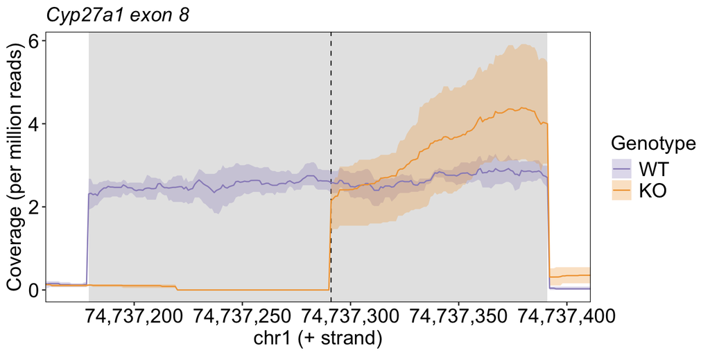

```r
p_e8 <- ggplot(e8_genotype, aes(x = pos)) +
  e8_layers +
  geom_ribbon(aes(ymin = min, ymax = max, fill = genotype), alpha = .3) +
  geom_line(aes(y = mean, color = genotype), linewidth = .5) +
  scale_fill_manual(values = genotype_colors) +
  scale_color_manual(values = genotype_colors) +
  theme(plot.title = element_text(face = "italic")) +
  labs(
    x = paste0(seqnames(locus), " (", gene_strand, " strand)"),
    y = "Coverage (per million reads)",
    color = "Genotype",
    fill = "Genotype",
    title = paste0(params$gene, " exon 8")
  )

save_fig(p_e8, "coverage_e8_zoom_genotype.pdf", 8, 4)
```

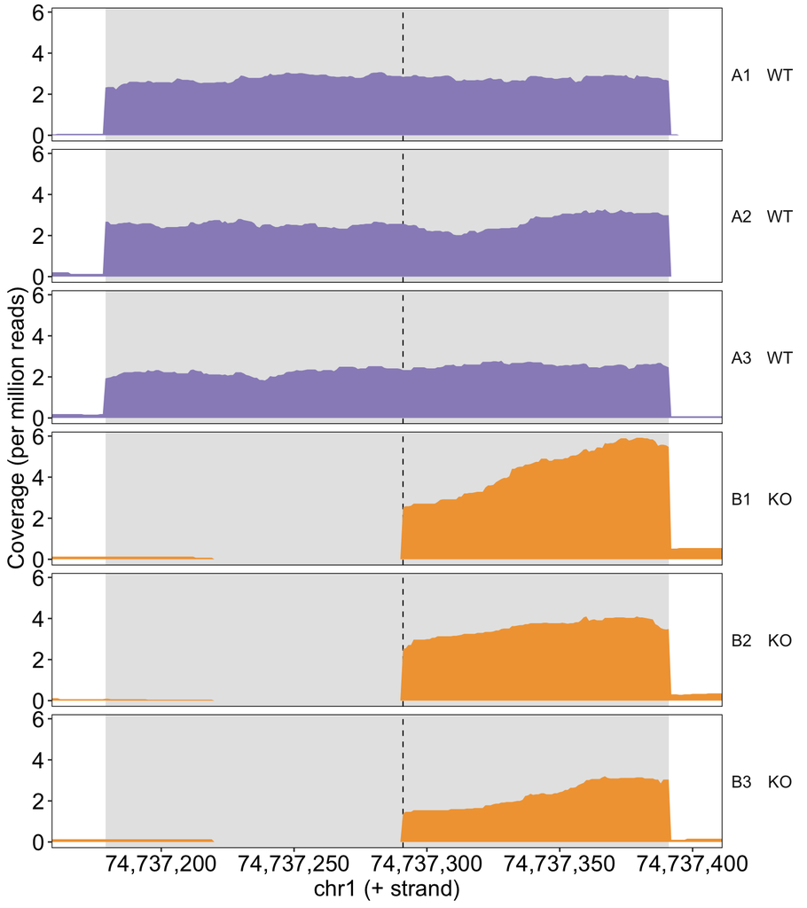

```r
p_e8_sample <- ggplot(cov_e8, aes(x = pos, y = cov)) +
  e8_layers +
  geom_area(aes(fill = genotype)) +
  facet_wrap(~ genotype + mouse, ncol = 1, strip.position = "right") +
  scale_fill_manual(values = genotype_colors) +
  theme(
    strip.background = element_blank(),
    strip.text.y = element_text(size = 12, angle = 0),
    legend.position = "none"
  ) +
  labs(
    x = paste0(seqnames(locus), " (", gene_strand, " strand)"),
    y = "Coverage (per million reads)"
  )

save_fig(p_e8_sample, "coverage_e8_zoom_sample.pdf", 8, 9)
```

## Per-exon summary

Mean coverage per exon. To separate a local loss (deleted exon) from an overall reduction of the transcript (e.g. nonsense-mediated decay), coverage is also shown relative to each sample’s mean over all exons.

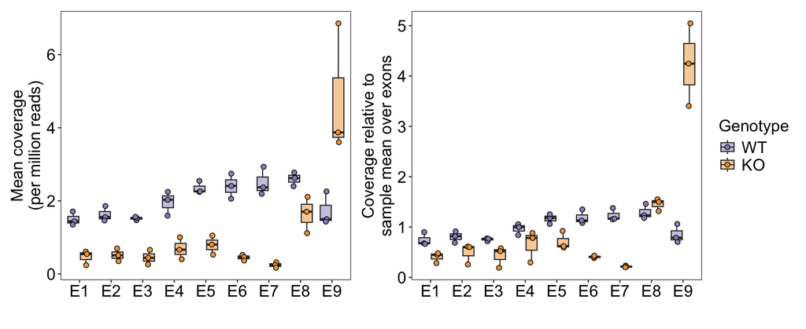

```r
exon_summary <- cov_exon_df |>
  group_by(sample_id, mouse, genotype, exon) |>
  summarise(mean_cov = mean(cov), .groups = "drop") |>
  group_by(sample_id) |>
  mutate(rel_cov = mean_cov / mean(mean_cov)) |>
  ungroup() |>
  mutate(exon = factor(exon, levels = levels(exon_df$exon)))

write.csv(exon_summary, file.path(files_dir, "exon_coverage_per_sample.csv"), row.names = FALSE)

exon_points <- function(y, ylab) {
  ggplot(exon_summary, aes(x = exon, y = {{ y }}, fill = genotype)) +
    geom_boxplot(outlier.alpha = 0, alpha = .5, position = position_dodge(.8), width = .7) +
    geom_point(shape = 21, size = 2, position = position_jitterdodge(jitter.width = .15, dodge.width = .8)) +
    scale_fill_manual(values = genotype_colors) +
    my_theme +
    labs(x = "", y = ylab, fill = "Genotype")
}

p_exon_summary <- (
  exon_points(mean_cov, "Mean coverage\n(per million reads)") |
    exon_points(rel_cov, "Coverage relative to\nsample mean over exons")
) +
  plot_layout(guides = "collect")

save_fig(p_exon_summary, "exon_coverage_summary.pdf", 11, 4.5)
```

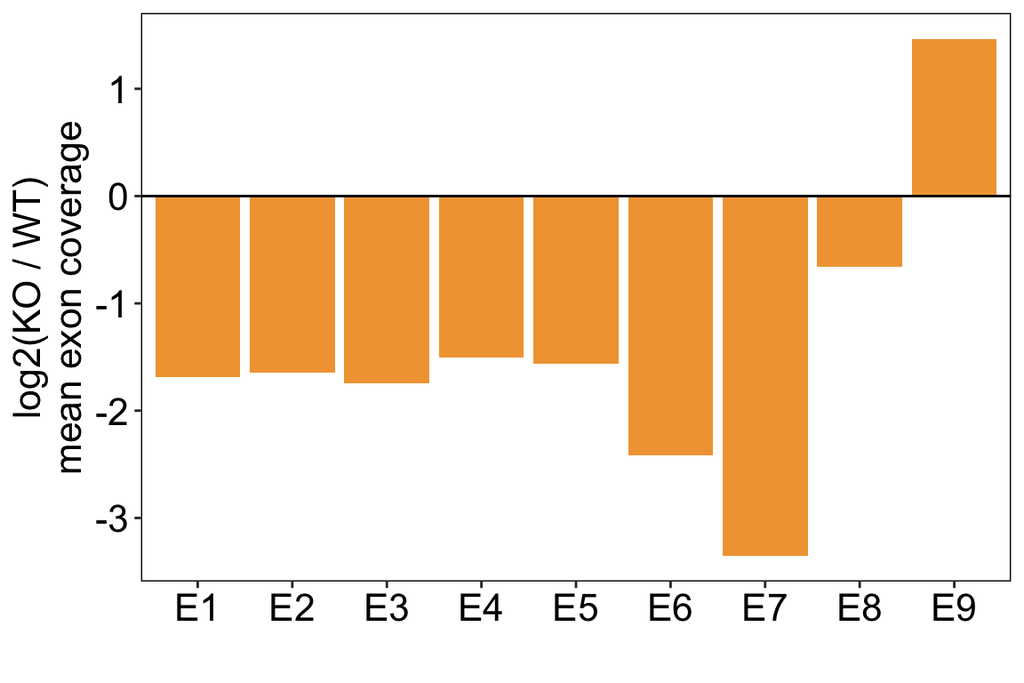

```r
exon_ratio <- exon_summary |>
  group_by(exon, genotype) |>
  summarise(mean_cov = mean(mean_cov), .groups = "drop") |>
  pivot_wider(names_from = genotype, values_from = mean_cov) |>
  mutate(log2_KO_WT = log2((KO + 1e-3) / (WT + 1e-3)))

write.csv(exon_ratio, file.path(files_dir, "exon_coverage_KO_vs_WT.csv"), row.names = FALSE)

p_ratio <- ggplot(exon_ratio, aes(x = exon, y = log2_KO_WT)) +
  geom_col(fill = genotype_colors["KO"]) +
  geom_hline(yintercept = 0) +
  my_theme +
  labs(x = "", y = "log2(KO / WT)\nmean exon coverage")

save_fig(p_ratio, "exon_coverage_ratio.pdf", 6, 4)
```

```r
knitr::kable(exon_ratio, digits = 3)
```

| exon | WT | KO | log2_KO_WT |
| --- | --- | --- | --- |
| E1 | 1.500 | 0.465 | -1.687 |
| E2 | 1.626 | 0.519 | -1.645 |
| E3 | 1.520 | 0.453 | -1.744 |
| E4 | 1.957 | 0.690 | -1.502 |
| E5 | 2.350 | 0.794 | -1.565 |
| E6 | 2.404 | 0.450 | -2.414 |
| E7 | 2.498 | 0.244 | -3.352 |
| E8 | 2.601 | 1.643 | -0.662 |
| E9 | 1.729 | 4.778 | 1.466 |

## Save outputs

```r
writeLines(capture.output(sessionInfo()), here("1_Cyp27a1_coverage", "sessionInfo.txt"))
```